# Day 10 - Categorical Variables and Nested F Tests

SDS 291

February 26, 2020

## Birthweight and parental smoking

- Response variable
  - `wt`: birth weight (in ounces)
- Explanatory Variable(s)
  - `smoke`: smoke does mother smoke? 0=never, 1=smokes now, 2=until current pregnancy, 3=once did, not now
  - `age`: mother’s age in years at termination of pregnancy

Bring in the data

```r
require(mosaic)
require(tidyverse)
require(magrittr)
data("Gestation")
Gestation<-Gestation %>% filter(!is.na(smoke), !is.na(wt))
```

Now fit the model:
$$bithweight=\beta_0+\beta_1 smoke+ \epsilon$$

```r
m_quant<-lm(wt~smoke, data=Gestation)
summary(m_quant)
```

```
##
## Call:
## lm(formula = wt ~ smoke, data = Gestation)
##
## Residuals:
##     Min      1Q  Median      3Q     Max
## -64.855 -10.855   0.274  11.145  56.145
##
## Coefficients:
##             Estimate Std. Error t value Pr(>|t|)
## (Intercept) 119.8553     0.6949  172.48   <2e-16 ***
## smoke        -0.4198     0.5749   -0.73    0.465
## ---
## Signif. codes:  0 '***' 0.001 '**' 0.01 '*' 0.05 '.' 0.1 ' ' 1
##
## Residual standard error: 18.21 on 1224 degrees of freedom
## Multiple R-squared:  0.0004353,  Adjusted R-squared:  -0.0003814
## F-statistic: 0.533 on 1 and 1224 DF,  p-value: 0.4655
```

1. How do you interpret the coefficient for `smoke`?

## What if smoking status were a categorical variable?

###R uses `factor` variables to indicate categorical variables.

You could make a new variable `smoke_factor` with the same values as `smoke` but where `R` knows the variable should be formatted as a factor.

```r
Gestation<-Gestation %>%
  mutate(smoke_factor=as.factor(smoke))
m_cat1<-lm(wt~smoke_factor, data=Gestation)
summary(m_cat1)
```

```
##
## Call:
## lm(formula = wt ~ smoke_factor, data = Gestation)
##
## Residuals:
##    Min     1Q Median     3Q    Max
## -67.78 -11.11   0.89  11.22  53.22
##
## Coefficients:
##               Estimate Std. Error t value Pr(>|t|)
## (Intercept)   122.7776     0.7583 161.904  < 2e-16 ***
## smoke_factor1  -8.6681     1.1052  -7.843 9.53e-15 ***
## smoke_factor2   0.3066     1.9668   0.156    0.876
## smoke_factor3   1.6593     1.9006   0.873    0.383
## ---
## Signif. codes:  0 '***' 0.001 '**' 0.01 '*' 0.05 '.' 0.1 ' ' 1
##
## Residual standard error: 17.69 on 1222 degrees of freedom
## Multiple R-squared:  0.05823,    Adjusted R-squared:  0.05592
## F-statistic: 25.19 on 3 and 1222 DF,  p-value: 8.196e-16
```

1. What is the average expected birthweight of a child whose mother never smoked?
1. Interpret the coefficient for `smoke_factor1`.
1. Interpret the coefficient for `smoke_factor2`.

It’s hard to keep the values of these levels straight. Especially if you had multiple factor variables. Instead, you might make the factor levels be something more conceptually understandable.

```r
Gestation<-Gestation %>%
  mutate(smoke_cat=as.factor(if_else(smoke==0,"never smoker",
                             if_else(smoke==1,"current smoker",
                             if_else(smoke==2,"pre-pregnancy smoker",
                             if_else(smoke==3,"other former smoker","NA"))))
                   )
        )
tally(~smoke_cat, data=Gestation)
```

```
## smoke_cat
##       current smoker         never smoker  other former smoker
##                  484                  544                  103
## pre-pregnancy smoker
##                   95
```

```r
smoke_factor_labels<-lm(wt~I(smoke_cat), data=Gestation)
summary(smoke_factor_labels)
```

```
##
## Call:
## lm(formula = wt ~ I(smoke_cat), data = Gestation)
##
## Residuals:
##    Min     1Q Median     3Q    Max
## -67.78 -11.11   0.89  11.22  53.22
##
## Coefficients:
##                                  Estimate Std. Error t value Pr(>|t|)
## (Intercept)                       114.109      0.804 141.933  < 2e-16 ***
## I(smoke_cat)never smoker            8.668      1.105   7.843 9.53e-15 ***
## I(smoke_cat)other former smoker    10.327      1.919   5.381 8.88e-08 ***
## I(smoke_cat)pre-pregnancy smoker    8.975      1.985   4.522 6.73e-06 ***
## ---
## Signif. codes:  0 '***' 0.001 '**' 0.01 '*' 0.05 '.' 0.1 ' ' 1
##
## Residual standard error: 17.69 on 1222 degrees of freedom
## Multiple R-squared:  0.05823,    Adjusted R-squared:  0.05592
## F-statistic: 25.19 on 3 and 1222 DF,  p-value: 8.196e-16
```

1. What is the average expected birthweight of a child whose mother never smoked?
1. What is the average expected birthweight of a child whose mother was a current smoker?

## How to get the right reference group?

You can tell `R` what you want the reference group to be with `relevel()` function.

```r
Gestation$smoke_cat<-relevel(Gestation$smoke_cat, ref = "never smoker")
```

But *the better option* is to make multiple indicator variables - one for each of the categories.

```r
Gestation<-Gestation %>%
  mutate(
    smoke_nev=if_else(smoke==0,1,0),
    smoke_cur=if_else(smoke==1,1,0),
    smoke_pre=if_else(smoke==2,1,0),
    smoke_fmr=if_else(smoke==3,1,0)
  )
tally(c("smoke_nev", "smoke_cur", "smoke_pre", "smoke_fmr"), data=Gestation)
```

```
## X
## smoke_cur smoke_fmr smoke_nev smoke_pre
##         1         1         1         1
```

```r
smoke_indicators<-lm(wt~smoke_nev+smoke_cur+smoke_pre+smoke_fmr, data=Gestation)
summary(smoke_indicators)
```

```
##
## Call:
## lm(formula = wt ~ smoke_nev + smoke_cur + smoke_pre + smoke_fmr,
##     data = Gestation)
##
## Residuals:
##    Min     1Q Median     3Q    Max
## -67.78 -11.11   0.89  11.22  53.22
##
## Coefficients: (1 not defined because of singularities)
##             Estimate Std. Error t value Pr(>|t|)
## (Intercept)  124.437      1.743  71.401  < 2e-16 ***
## smoke_nev     -1.659      1.901  -0.873    0.383
## smoke_cur    -10.327      1.919  -5.381 8.88e-08 ***
## smoke_pre     -1.353      2.516  -0.538    0.591
## smoke_fmr         NA         NA      NA       NA
## ---
## Signif. codes:  0 '***' 0.001 '**' 0.01 '*' 0.05 '.' 0.1 ' ' 1
##
## Residual standard error: 17.69 on 1222 degrees of freedom
## Multiple R-squared:  0.05823,    Adjusted R-squared:  0.05592
## F-statistic: 25.19 on 3 and 1222 DF,  p-value: 8.196e-16
```

## What does the ANOVA table tell us?

```r
anova(smoke_indicators)
```

```
## Analysis of Variance Table
##
## Response: wt
##             Df Sum Sq Mean Sq F value    Pr(>F)
## smoke_nev    1  10385 10385.4  33.197 1.053e-08 ***
## smoke_cur    1  13162 13162.3  42.074 1.274e-10 ***
## smoke_pre    1     90    90.4   0.289    0.5909
## Residuals 1222 382290   312.8
## ---
## Signif. codes:  0 '***' 0.001 '**' 0.01 '*' 0.05 '.' 0.1 ' ' 1
```

1. What’s the MSModel?

## What about a more parsimonious model?

Webster’s Dictionary defines parsimony as “the quality of being careful with money or resources.” Essentially, we use parsimonious as an adjective to describe a simpler model; we’re being careful with our degrees of freedom and number of coefficients in the model, and would prefer to “spend” fewer of them. A simpler model is generally better – it’s easier to explain.

```r
Gestation<-Gestation %>%
  mutate(smoke_cur_d=as.factor(if_else(smoke==1,"Smoker","NonSmoker")))
smoke_cur_d<-lm(wt~smoke_cur_d, data=Gestation)
summary(smoke_cur_d)
```

```
##
## Call:
## lm(formula = wt ~ smoke_cur_d, data = Gestation)
##
## Residuals:
##    Min     1Q Median     3Q    Max
## -68.05 -11.05   0.89  10.95  52.95
##
## Coefficients:
##                   Estimate Std. Error t value Pr(>|t|)
## (Intercept)        123.047      0.649 189.597   <2e-16 ***
## smoke_cur_dSmoker   -8.938      1.033  -8.653   <2e-16 ***
## ---
## Signif. codes:  0 '***' 0.001 '**' 0.01 '*' 0.05 '.' 0.1 ' ' 1
##
## Residual standard error: 17.68 on 1224 degrees of freedom
## Multiple R-squared:  0.05764,    Adjusted R-squared:  0.05687
## F-statistic: 74.87 on 1 and 1224 DF,  p-value: < 2.2e-16
```

1. How does this change our interpretation of `smoke_cur_d`?
1. Do we need the 4 category variable or is the dichotomous/binary variable enough?

```r
anova(smoke_cur_d,smoke_indicators)
```

```
## Analysis of Variance Table
##
## Model 1: wt ~ smoke_cur_d
## Model 2: wt ~ smoke_nev + smoke_cur + smoke_pre + smoke_fmr
##   Res.Df    RSS Df Sum of Sq      F Pr(>F)
## 1   1224 382529
## 2   1222 382290  2     238.6 0.3813  0.683
```

What we want to do is to test whether the model with four categories of smoking is *better* than the a binary definition of smoking (current vs. not current, which includes never, former, and smokers until pregnancy). Essentially, is the right plot with a binary explanatory variable better than the left of a model with four categories of `smoke`:

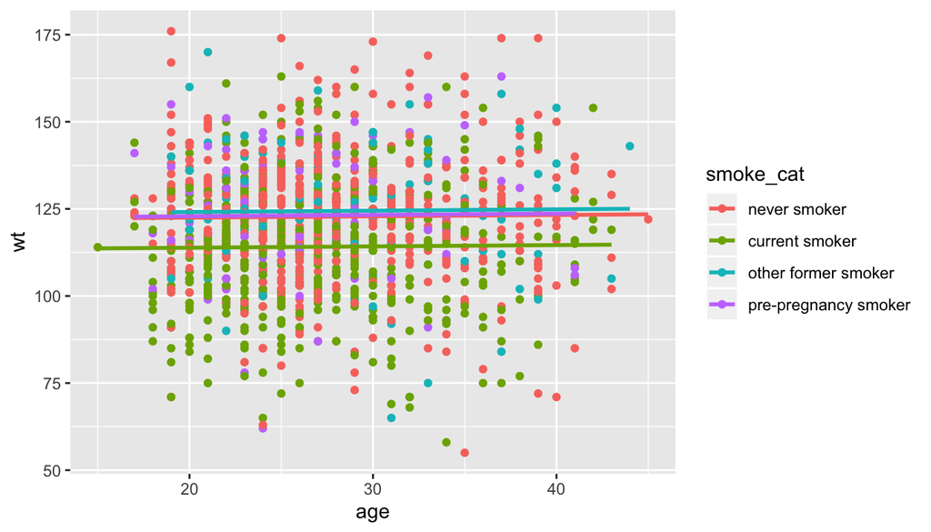

```r
library(moderndive)
qplot(y=wt, x=age, color=smoke_cat, data=Gestation)+geom_parallel_slopes(se=FALSE)
```

```r
wt4cat_temp<-lm(wt~smoke_cat+age, data=Gestation)
```

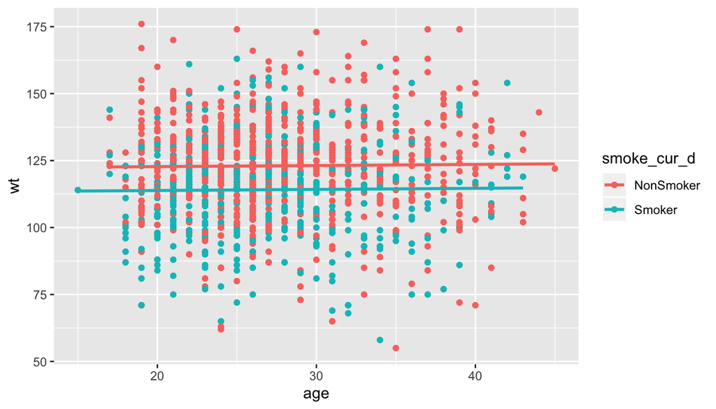

```r
qplot(y=wt, x=age, color=smoke_cur_d, data=Gestation)+geom_parallel_slopes(se=FALSE)
```

```r
smoke_cur_dage<-lm(wt~smoke_cur_d+age, data=Gestation)
```

We are essentially testing the hypothesis that former smokers and quit at pregnancy are the same as never smokers vs. the alternative that one of them is different.

$$H_0: \beta_\text{former} = \beta_\text{quit-at-pregancy} = 0$$
$$H_A: \beta_i \neq 0$$

##### Nested Model

```r
anova(smoke_cur_dage)
```

```
## Analysis of Variance Table
##
## Response: wt
##               Df Sum Sq Mean Sq F value Pr(>F)
## smoke_cur_d    1  23393 23392.7 74.6822 <2e-16 ***
## age            1     67    66.6  0.2126 0.6448
## Residuals   1221 382454   313.2
## ---
## Signif. codes:  0 '***' 0.001 '**' 0.01 '*' 0.05 '.' 0.1 ' ' 1
```

##### Full Model

```r
anova(wt4cat_temp)
```

```
## Analysis of Variance Table
##
## Response: wt
##             Df Sum Sq Mean Sq F value    Pr(>F)
## smoke_cat    3  23632  7877.2 25.1221 8.991e-16 ***
## age          1     58    57.9  0.1848    0.6674
## Residuals 1219 382224   313.6
## ---
## Signif. codes:  0 '***' 0.001 '**' 0.01 '*' 0.05 '.' 0.1 ' ' 1
```

##### Nested F Test

```r
anova(smoke_cur_dage, wt4cat_temp)
```

```
## Analysis of Variance Table
##
## Model 1: wt ~ smoke_cur_d + age
## Model 2: wt ~ smoke_cat + age
##   Res.Df    RSS Df Sum of Sq     F Pr(>F)
## 1   1221 382454
## 2   1219 382224  2    230.14 0.367 0.6929
```

The nested-F test is
$$Nested F = \frac{\frac{SSM_\text{full}-SSM_\text{nested}}{\text{Number of predictors}}}{\frac{SSE_\text{Full}}{n-k-1}}$$

We fail to reject the null hypothesis (the F statistic is very small, <1, and the p-value is very large and above our standard threshold 0.69>0.05) and conclude that we don’t have evidence that former and quit-at-pregnancy aren’t the same as each other. Thus, a model with just non-smokers vs. smokers does just as well as a model with all four categories (current vs. never, former, quit-at-pregnancy).